# Simulation of neuronal activity, III

W. Bauer

June 30, 2015

The previous note discussed the possibility of simulating neuronal activity on the scale of one Hodgkin-Huxley compartment per voxel. It estimated that 25 compartments per 1 mm<sup>3</sup> voxel might be necessary, but preliminary runs suggested as few as five might be adequate: The mean response of five compartments to five individual stimuli was closely approximated by the response of a single compartment to the average of the five individual stimuli.

Here we are interested in comparing the mean response of 25 compartments to the response of a single compartment to the average of the 25 stimuli. The stimuli will consist of stylized, but otherwise random, excitations from 0 to 50 ms, followed by similar inhibitory stimuli beginning at 30 ms and lasting until 80 ms, as illustrated below.

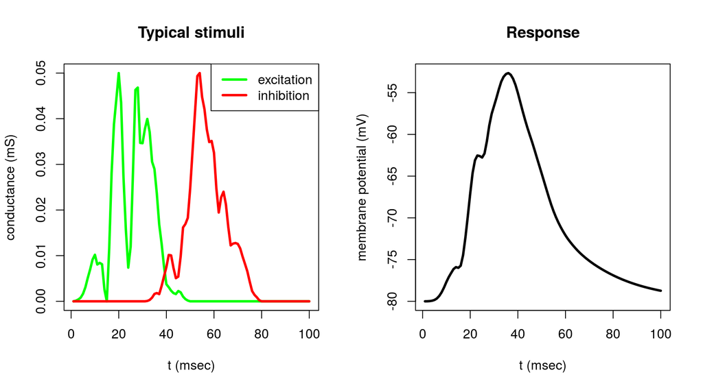

The following shows a histogram of 100 trials in which the correlation coefficient was computed between the mean response of 25 compartments and the response of 1 compartment to the mean stimulus. As can be seen correlation coefficients are very high, averging 0.98. This implies the two have essentially the same shape, consistent with observations in the literature. It does not imply they have the same amplitude since the correlation coefficient just measures the cosine of the angle between the two. However, since shape and timing are of primary interest, the result supports the adequacy of simulation of neuronal activity on scales of one compartment per voxel.

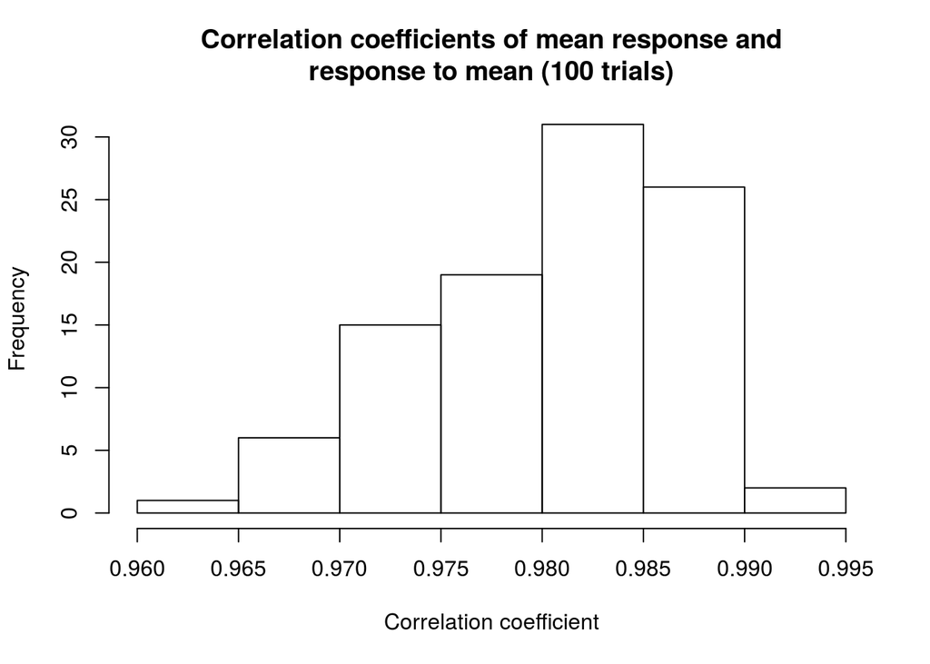